# Terra votes

Manuel Girbal

17/4/2022

## Introduction

In this work I’ll try to answer one question: how much voting power (measured in LUNA) was used to vote ‘YES’ for governance proposals in the Terra ecosystem? In doing so, I’ll differentiate validators vs regular wallets.

### Methodology

Data was queried from Flipside Crypto’s Velocity database, and the SQL code used is shown below. The result of this chunk is a dataset containing both average voting power and number of addresses that voted yes in each proposal, taking into account which addresses are related to Terra validators and which to regular users:

```sql
select proposal_id::number as id,
       case
          when voter in (select address from terra.labels where label_subtype = 'validator') then 'validator'
          else 'regular'
       end as validator_vs_regular,
       count(voter) as n,
       avg(voting_power) as mean_voting_power_YES
from terra.gov_vote
where option = 'VOTE_OPTION_YES'
group by proposal_id, validator_vs_regular
```

### Analysis

First we will see how many addresses voted yes per proposal, and how many belong to validators vs regular users:

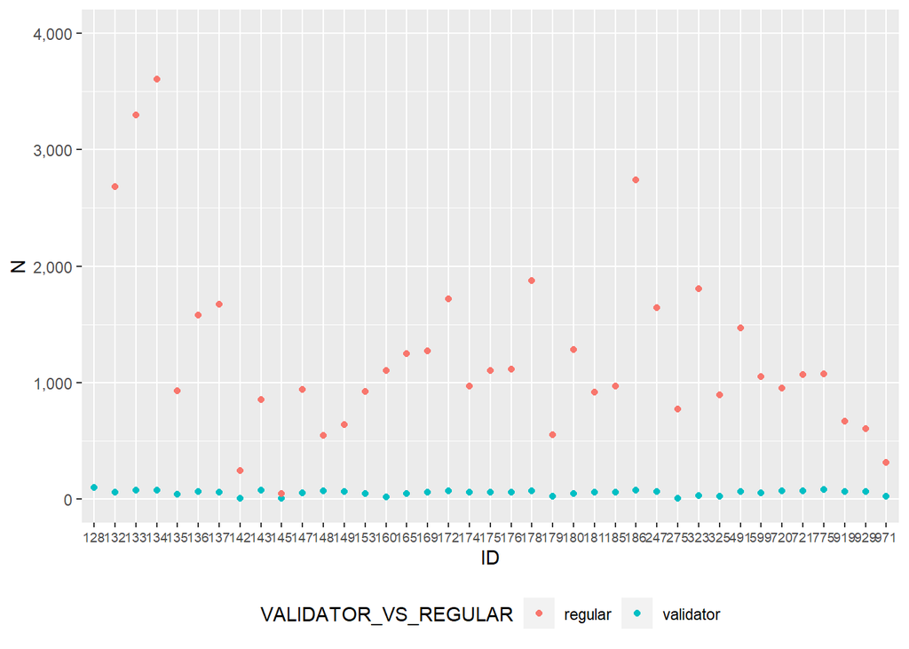

From this plot we can observe that validators addresses that vote yes tend to be between 5 and 100, while individual user addresses range mostly from 250 to 3500. It all depends on the issue at stake, so taking into account which topic was discussed and voted in each proposal might be helpful to understand participation.

As regards to the average voting power used in each proposal:

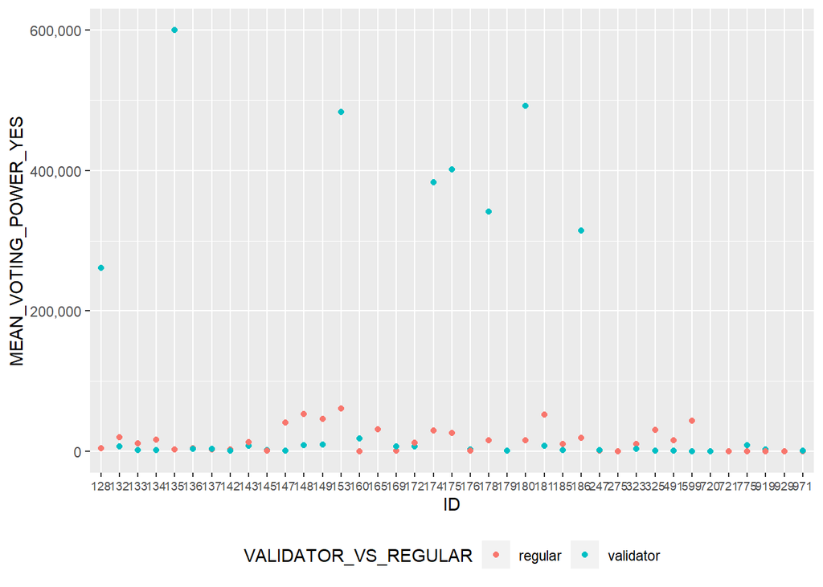

Here we can see that average voting power from both validators and regular users tends to be more similar, although we already saw that regular users represent more individual addresses than validators. Of course, here we’re not taking into account how many delegators have conceded voting power to validators, which should be also interesting to see.

One last note regarding voting power: there are some special proposal IDs which saw peaks between 400k and 600k LUNA from validators, which tells us that those specific issues might have been more critical than others.

### Conclusion

From the plots above we can say that there are more individual addresses participating (and voting yes) on governance proposals than validators addresses, and that average voting power tends to be similar except for some specific proposals that appeared to be more critical for validators, which ended in more voting power being put at stake from them to decide the outcome of that proposals.

This analysis, however, leaves us with the following questions to be answered:

- Which specific issues being discussed generated more participation from both validators and individual users that don’t delegate their voting power?
- How many addresses delegate to those validators? This measure can be used to compare with the numbers we saw from individual addresses that don’t delegate voting power.

### References

https://flipsidecrypto.xyz/

https://docs.terra.money/docs/develop/module-specifications/spec-governance.html

https://docs.terra.money/docs/full-node/manage-a-terra-validator/faq.html

Code used for this publication: https://github.com/manuelgirbal/flipside